# Cobinding PiPeline: pre processing & analysis

```python
import os
import pandas as pd
import sys
sys.path.insert(0, '../..')
import itertools
from scipy import stats

import numpy as np

from JKBio.epigenetics import chipseq as chip
from JKBio.utils import helper
from JKBio.utils import plot
from JKBio.google import gcp
import igv
import SimpSOM as sps
from scipy import stats

import seaborn as sns
from matplotlib import cm
from matplotlib import pyplot as plt
from IPython.display import IFrame
import seaborn as sns
from bokeh.plotting import *
import igv

import numba
from numba import jit

from scipy.cluster.hierarchy import linkage, leaves_list
from sklearn.cluster import AgglomerativeClustering, DBSCAN, KMeans, OPTICS
from sklearn.mixture import GaussianMixture
from sklearn.manifold import MDS, TSNE
from sklearn.decomposition import PCA
from sklearn.preprocessing import scale
from IPython.display import IFrame

from pybedtools import BedTool
import pyBigWig

output_notebook()
%load_ext autoreload
%autoreload 2
```

```
The autoreload extension is already loaded. To reload it, use:
  %reload_ext autoreload
```

```python
project="Cobinding_ChIP"
version="v3"
```

## processing using Nextflow

```python
fastq = ! gsutil ls gs://amlproject/Chip/fastqs/paired_end/*MV411* # all other cell lines don't have the right INPUT
fastq
```

```
['gs://amlproject/Chip/fastqs/paired_end/mp299-MV411-CEBPA-r3_S7_R1.fastq.gz',
 'gs://amlproject/Chip/fastqs/paired_end/mp299-MV411-CEBPA-r3_S7_R2.fastq.gz',
 'gs://amlproject/Chip/fastqs/paired_end/mp300-MV411-RUNX1-r3_S8_R1.fastq.gz',
 'gs://amlproject/Chip/fastqs/paired_end/mp300-MV411-RUNX1-r3_S8_R2.fastq.gz',
 'gs://amlproject/Chip/fastqs/paired_end/mp301-MV411-PU1-r2_R1.fastq.gz',
 'gs://amlproject/Chip/fastqs/paired_end/mp301-MV411-PU1-r2_R2.fastq.gz',
 'gs://amlproject/Chip/fastqs/paired_end/mp319-MV411-FLI1-r1_R1.fastq.gz',
 'gs://amlproject/Chip/fastqs/paired_end/mp319-MV411-FLI1-r1_R2.fastq.gz',
 'gs://amlproject/Chip/fastqs/paired_end/mp320-MV411-ZEB2-r1_R1.fastq.gz',
 'gs://amlproject/Chip/fastqs/paired_end/mp320-MV411-ZEB2-r1_R2.fastq.gz',
 'gs://amlproject/Chip/fastqs/paired_end/mp321-MV411-GFI1-r1_R1.fastq.gz',
 'gs://amlproject/Chip/fastqs/paired_end/mp321-MV411-GFI1-r1_R2.fastq.gz',
 'gs://amlproject/Chip/fastqs/paired_end/mp324-MV411-MEF2D-r1_R1.fastq.gz',
 'gs://amlproject/Chip/fastqs/paired_end/mp324-MV411-MEF2D-r1_R2.fastq.gz',
 'gs://amlproject/Chip/fastqs/paired_end/mp325-MV411-SP1-r2_R1.fastq.gz',
 'gs://amlproject/Chip/fastqs/paired_end/mp325-MV411-SP1-r2_R2.fastq.gz',
 'gs://amlproject/Chip/fastqs/paired_end/mp845-MV411-INPUT-r2_R1.fastq.gz',
 'gs://amlproject/Chip/fastqs/paired_end/mp845-MV411-INPUT-r2_R2.fastq.gz',
 'gs://amlproject/Chip/fastqs/paired_end/mp874-MV411_MEF2D_NT_SC_63-FLAG_MEF2D-r2_R1_001.fastq.gz',
 'gs://amlproject/Chip/fastqs/paired_end/mp874-MV411_MEF2D_NT_SC_63-FLAG_MEF2D-r2_R2_001.fastq.gz',
 'gs://amlproject/Chip/fastqs/paired_end/mp875-MV411_MEF2C_NT-FLAG_MEF2C-r1_R1_001.fastq.gz',
 'gs://amlproject/Chip/fastqs/paired_end/mp875-MV411_MEF2C_NT-FLAG_MEF2C-r1_R2_001.fastq.gz',
 'gs://amlproject/Chip/fastqs/paired_end/mp876-MV411-ZFP281-r1_R1_001.fastq.gz',
 'gs://amlproject/Chip/fastqs/paired_end/mp876-MV411-ZFP281-r1_R2_001.fastq.gz',
 'gs://amlproject/Chip/fastqs/paired_end/mp877-MV411-PLAGL2-r1_R1_001.fastq.gz',
 'gs://amlproject/Chip/fastqs/paired_end/mp877-MV411-PLAGL2-r1_R2_001.fastq.gz',
 'gs://amlproject/Chip/fastqs/paired_end/mp878-MV411-HEX-r1_R1_001.fastq.gz',
 'gs://amlproject/Chip/fastqs/paired_end/mp878-MV411-HEX-r1_R2_001.fastq.gz',
 'gs://amlproject/Chip/fastqs/paired_end/mp879-MV411-FOSL2-r1_R1_001.fastq.gz',
 'gs://amlproject/Chip/fastqs/paired_end/mp879-MV411-FOSL2-r1_R2_001.fastq.gz',
 'gs://amlproject/Chip/fastqs/paired_end/mp880-MV411-RARA-r1_R1_001.fastq.gz',
 'gs://amlproject/Chip/fastqs/paired_end/mp880-MV411-RARA-r1_R2_001.fastq.gz',
 'gs://amlproject/Chip/fastqs/paired_end/mp913-MV411-TFP4-r1_R1_001.fastq.gz',
 'gs://amlproject/Chip/fastqs/paired_end/mp913-MV411-TFP4-r1_R2_001.fastq.gz',
 'gs://amlproject/Chip/fastqs/paired_end/mp914-MV411-RXRA-r1_R1_001.fastq.gz',
 'gs://amlproject/Chip/fastqs/paired_end/mp914-MV411-RXRA-r1_R2_001.fastq.gz',
 'gs://amlproject/Chip/fastqs/paired_end/mp915-MV411_MEF2C_NT-MEF2C-r2_R1_001.fastq.gz',
 'gs://amlproject/Chip/fastqs/paired_end/mp915-MV411_MEF2C_NT-MEF2C-r2_R2_001.fastq.gz']
```

```python
from gsheets import Sheets
# Here you might not need this line, otherwise you need to generate your json files from
# https://pygsheets.readthedocs.io/en/stable/authorization.html
sheets = Sheets.from_files('~/.client_secret.json', '~/.storage.json')
url="https://docs.google.com/spreadsheets/d/1yFLjYB1McU530JnLgL0QIMAKIkVl3kl0_LCHje2gk8U"
gsheet = sheets.get(url).sheets[2].to_frame()
```

```python
df = {
"fastq_1": [],
"fastq_2": [],
"antibody": [],
"group": [],
"replicate": [],
"control": []
}
for val in helper.grouped(fastq,2):
    row = gsheet[gsheet.id==val[0].split('/')[-1].split('-')[0]]
    df['group'].append(row['name'].values[0].split('-r')[0])
    df['replicate'].append(1)
    df['fastq_1'].append(val[0])
    df['fastq_2'].append(val[1])
    if row['matching input name'].values[0] is not None:
        df['antibody'].append(row['protein'].values[0])
        cont = gsheet[gsheet.id==row['matching input name'].values[0]]
        df['control'].append(cont['name'].values[0].split('-r')[0])
    else:
        df['antibody'].append("")
        df['control'].append("")
df = pd.DataFrame(df)
df[df.columns[[3,4,0,1,2,5]]].to_csv('../nextflow/'+project+'_paired_end_design.csv',index=False)
```

```python
fastq = ! gsutil ls gs://amlproject/Chip/fastqs/*.gz
fastq
```

```
['gs://amlproject/Chip/fastqs/db28-MV411-H3K18-r1.fastq.gz',
 'gs://amlproject/Chip/fastqs/db29-MV411-AFF4-r1.fastq.gz',
 'gs://amlproject/Chip/fastqs/db30-MV411-CDK9-r1.fastq.gz',
 'gs://amlproject/Chip/fastqs/db31-MV411-PSER2-r1.fastq.gz',
 'gs://amlproject/Chip/fastqs/db32-MV411-INPUT-r1.fastq.gz',
 'gs://amlproject/Chip/fastqs/db33-MV411-INPUT-r2.fastq.gz',
 'gs://amlproject/Chip/fastqs/db34-MV411-CEBPB-r1.fastq.gz',
 'gs://amlproject/Chip/fastqs/db35-MV411-INPUT-r3.fastq.gz',
 'gs://amlproject/Chip/fastqs/db36-MV411-INPUT-r4.fastq.gz',
 'gs://amlproject/Chip/fastqs/db37-MV411-WDR5_429A-r1.fastq.gz',
 'gs://amlproject/Chip/fastqs/db38-MV411-WDR5_429A-r2.fastq.gz',
 'gs://amlproject/Chip/fastqs/db39-MV411-WDR5_429A-r3.fastq.gz',
 'gs://amlproject/Chip/fastqs/db40-MV411-WDR5_D9E1-r1.fastq.gz',
 'gs://amlproject/Chip/fastqs/db41-MV411-WDR5_D9E1-r2.fastq.gz',
 'gs://amlproject/Chip/fastqs/db42-MV411-WDR5_D9E1-r3.fastq.gz',
 'gs://amlproject/Chip/fastqs/db43-MV411-IGG-r1.fastq.gz',
 'gs://amlproject/Chip/fastqs/db44-MV411-IGG-r2.fastq.gz',
 'gs://amlproject/Chip/fastqs/db45-MV411-IGG-r3.fastq.gz',
 'gs://amlproject/Chip/fastqs/db46-MV411-BRD4-r1.fastq.gz',
 'gs://amlproject/Chip/fastqs/db47-MV411-BRD4-r2.fastq.gz',
 'gs://amlproject/Chip/fastqs/db48-MV411-INPUT-r5.fastq.gz',
 'gs://amlproject/Chip/fastqs/db49-MV411-INPUT-r6.fastq.gz',
 'gs://amlproject/Chip/fastqs/db50-MV411-AFF1_AF4-r1.fastq.gz',
 'gs://amlproject/Chip/fastqs/db51-MV411-H3K36me2-r1.fastq.gz',
 'gs://amlproject/Chip/fastqs/db52-MV411-INPUT-r7.fastq.gz',
 'gs://amlproject/Chip/fastqs/db53-MV411-H3K9ac-r1.fastq.gz',
 'gs://amlproject/Chip/fastqs/db54-MV411-INPUT-r8.fastq.gz',
 'gs://amlproject/Chip/fastqs/db55-MV411-RUNX1-r1.fastq.gz',
 'gs://amlproject/Chip/fastqs/db56-MV411-MLL_KTM2A-r1.fastq.gz',
 'gs://amlproject/Chip/fastqs/mp100-U937-INPUT-r1.fastq.gz',
 'gs://amlproject/Chip/fastqs/mp101-NOMO1-INPUT-r1.fastq.gz',
 'gs://amlproject/Chip/fastqs/mp102-UT7-INPUT-r1.fastq.gz',
 'gs://amlproject/Chip/fastqs/mp106-MV411-MYB-r1.fastq.gz',
 'gs://amlproject/Chip/fastqs/mp109-M6-CEBPA-r1.fastq.gz',
 'gs://amlproject/Chip/fastqs/mp112-MV411-CEBPA-r1.fastq.gz',
 'gs://amlproject/Chip/fastqs/mp115-MV411-PU1-r1.fastq.gz',
 'gs://amlproject/Chip/fastqs/mp116-MV411-MYB-r2.fastq.gz',
 'gs://amlproject/Chip/fastqs/mp117-MV411-POLII-r1.fastq.gz',
 'gs://amlproject/Chip/fastqs/mp118-MV411-SP1-r1.fastq.gz',
 'gs://amlproject/Chip/fastqs/mp120-HL60-INPUT-r1.fastq.gz',
```

[output cut: 168 more lines]

```
 'gs://amlproject/Chip/fastqs/mp770-MV411-MYBL2-r1.fastq.gz',
 'gs://amlproject/Chip/fastqs/mp771-MV411-JUND-r1.fastq.gz',
 'gs://amlproject/Chip/fastqs/mp772-MV411-JUND-r2.fastq.gz',
 'gs://amlproject/Chip/fastqs/mp773-MV411-HOXA9-r1.fastq.gz',
 'gs://amlproject/Chip/fastqs/mp774-MV411-HOXA9-r2.fastq.gz',
 'gs://amlproject/Chip/fastqs/mp776-P31FUJ-H3K27ac-r1.fastq.gz',
 'gs://amlproject/Chip/fastqs/mp777-MONOMAC1-H3K27ac-r3.fastq.gz',
 'gs://amlproject/Chip/fastqs/mp778-MONOMAC1-H3K27ac-r4.fastq.gz',
 'gs://amlproject/Chip/fastqs/mp8-D0-INPUT-r2.fastq.gz',
 'gs://amlproject/Chip/fastqs/mp88-MV411-H3K27ac-r3.fastq.gz',
 'gs://amlproject/Chip/fastqs/mp89-MV411-H3K36me3-r1.fastq.gz',
 'gs://amlproject/Chip/fastqs/mp90-U937-H3K27ac-r3.fastq.gz',
 'gs://amlproject/Chip/fastqs/mp92-NOMO1-H3K27ac-r2.fastq.gz',
 'gs://amlproject/Chip/fastqs/mp98-M6-INPUT-r1.fastq.gz',
 'gs://amlproject/Chip/fastqs/mp99-MV411-INPUT-r1.fastq.gz']
```

```python
df = {
"fastq_1": [],
"fastq_2": [],
"antibody": [],
"group": [],
"replicate": [],
"control": []
}
for val in fastq:
    row = gsheet[gsheet.id==val.split('/')[-1].split('-')[0]]
    if row['protein'].values[0] in ["IRF2BP2", "H3K27ac", "H3K36me3", "H3K27me3", "MED1", "H3K79me2", "H3K4me3", "H3K4me1", "H3K36me2", "H3K9ac", "H3K18", "BRD4"]:
        continue
    df['group'].append(row['name'].values[0].split('-r')[0])
    df['replicate'].append(1)
    df['fastq_1'].append(val)
    df['fastq_2'].append("")
    if row['matching input name'].values[0] is not None and row['matching input name'].values[0] is not np.nan:
        df['antibody'].append(row['protein'].values[0])
        cont = gsheet[gsheet.id==row['matching input name'].values[0]]
        df['control'].append(cont['name'].values[0].split('-r')[0])
    else:
        df['antibody'].append("")
        df['control'].append("")
df = pd.DataFrame(df)
df[df.columns[[3,4,0,1,2,5]]].to_csv('../nextflow/'+project+'_single_end_design_np.csv',index=False)
```

```python
df = {
"fastq_1": [],
"fastq_2": [],
"antibody": [],
"group": [],
"replicate": [],
"control": []
}
for val in fastq:
    row = gsheet[gsheet.id==val.split('/')[-1].split('-')[0]]
    if row['protein'].values[0] not in ['INPUT',"IGG","IRF2BP2", "H3K27ac", "CEBPA", "H3K36me3", "PU1", "H3K27me3", "SMC1", "MED1", "H3K79me2", "H3K4me3", "H3K4me1", "H3K36me2", "H3K9ac", "CEBPB", "H3K18", "BRD4", "WDR5"]:
        continue
    df['group'].append(row['name'].values[0].split('-r')[0])
    df['replicate'].append(1)
    df['fastq_1'].append(val)
    df['fastq_2'].append("")
    if row['matching input name'].values[0] is not None and row['matching input name'].values[0] is not np.nan:
        df['antibody'].append(row['protein'].values[0])
        cont = gsheet[gsheet.id==row['matching input name'].values[0]]
        df['control'].append(cont['name'].values[0].split('-r')[0])
    else:
        df['antibody'].append("")
        df['control'].append("")
df = pd.DataFrame(df)
df[df.columns[[3,4,0,1,2,5]]].to_csv('../nextflow/'+project+'_single_end_design_bp.csv',index=False)
```

## Pipeline

[figure not shown]

- Raw read QC (FastQC)
- Adapter trimming (Trim Galore!)
- Alignment (BWA)
- Mark duplicates (picard)
- Merge alignments from multiple libraries of the same sample (picard)
- Re-mark duplicates (picard)
- Filtering to remove: blacklisted regions, duplicates, primary alignments,unmapped,multiple locations, containing > 4 mismatches, insert size > 2kb, map to different chromosomes
- Alignment-level QC and estimation of library complexity (picard, Preseq)
- Create normalised bigWig files scaled to 1 million mapped reads (BEDTools, bedGraphToBigWig)
- Generate gene-body meta-profile from bigWig files (deepTools)
- Calculate genome-wide IP enrichment relative to control (deepTools)
- Calculate strand cross-correlation peak and ChIP-seq quality measures including NSC and RSC (phantompeakqualtools)
- Call broad/narrow peaks (MACS2)
- Annotate peaks relative to gene features (HOMER)
- Create consensus peakset across all samples and create tabular file to aid in the filtering of the data (BEDTools)
- Count reads in consensus peaks (featureCounts)

[figure not shown]

## about

1. you need to have a google project set up with a billing account
2. you need to activte your APIs this way: https://cloud.google.com/life-sciences/docs/tutorials/nextflow?hl=fr
3. nextflow needs to be installed with this installation command `export NXF_MODE=google && curl https://get.nextflow.io | bash`
4. you will export the credentials to your google account (see google cloud oauth) `export GOOGLE_APPLICATION_CREDENTIALS=aml-chipseq-rnaseq-9dcbe47182cf.json`
5. look more about the chipseq pipeline here: https://nf-co.re/chipseq
6. now you can run the code as below (to run it locally, use `-profile docker`)
7. to run it on google cloud make a conf file with your google paymnt project id: `echo "google.project = 'YOUR_GOOGLE_PROJECT_ID'" >> my.config` and run the pipeline using: `-profile jkcloud --custom_local_config my.config`
8. to run it elsewhere, look at nf-core's documentation

```python
-profile #my profile for the cloud (to edit for your account) jkcloud
-w #where the withinput will be stored
--outdir #specify aa bucket+folderr where the results will be
--tracedir #you need to specify a local place for that
--custom_local_config custom_local.config #yoour custtom config
```

```python
#process chips
! ../../nextflow run jkobject/chipseq --paired_end --seq_center 'multiple' --email 'jkobject@gmail.com' --input ../nextflow/$project_paired_end_design.csv --genome 'GRCh38' --max_cpus 16 -profile 'jkcloud' -w gs://workamlproject/cobindingp --outdir gs://workamlproject/cobindingpres --tracedir ../nextflow/cobindingp/ --narrow_peak
```

```
.nextflow/history.lock (Permission denied)
```

```python
#calling narrow peak proteins in single end
! ../../nextflow run jkobject/chipseq --single_end --seq_center 'multiple' --email 'jkobject@gmail.com' --input ../nextflow/$project_single_end_design.csv --genome 'GRCh38' --max_cpus 16 -profile 'jkcloud' -w gs://workamlproject/cobindings --outdir gs://workamlproject/cobindingsres --tracedir ../nextflow/cobindings/ --narrow_peak
```

```python
#calling broad peak proteins in single end
! ../../nextflow run jkobject/chipseq --single_end --seq_center 'multiple' --email 'jkobject@gmail.com' --input ../nextflow/$project_single_end_broad_design.csv --genome 'GRCh38' --max_cpus 16 -profile 'jkcloud' -w gs://workamlproject/cobindingsb --outdir gs://workamlproject/cobindingsbres --tracedir ../nextflow/cobindingsb/
```

## Gathering data

we are using a folder outside our repository as there is too many huge files.

```python
! gsutil -m cp -r gs://workamlproject/cobindingpres/* gs://amlproject/Chip/res/
#rename files: doing it once for each copy _pe, _se_bp, _se_np
helper.parrun(['gsutil mv '+i+' '+i.split('.')[0]+'_pe_np.'+i.split('.')[1] for i in ["gs://amlproject/Chip/res/multiqc/narrowPeak/multiqc_report.html",
"gs://amlproject/Chip/res/igv/narrowPeak/igv_files.txt",
"gs://amlproject/Chip/res/igv/narrowPeak/igv_session.xml",
"gs://amlproject/Chip/res/pipeline_info/design_controls.csv",
"gs://amlproject/Chip/res/pipeline_info/design_reads.csv",
"gs://amlproject/Chip/res/pipeline_info/results_description.html",
"gs://amlproject/Chip/res/pipeline_info/software_versions.csv"]],cores=8)
```

```python
! gsutil -m cp -r gs://workamlproject/cobindingsbpres/* gs://amlproject/Chip/res/
#rename files: doing it once for each copy _pe, _se_bp, _se_np
helper.parrun(['gsutil mv '+i+' '+i.split('.')[0]+'_se_bp.'+i.split('.')[1] for i in ["gs://amlproject/Chip/res/multiqc/broadPeak/multiqc_report.html",
"gs://amlproject/Chip/res/igv/narrowPeak/igv_files.txt",
"gs://amlproject/Chip/res/igv/narrowPeak/igv_session.xml",
"gs://amlproject/Chip/res/pipeline_info/design_controls.csv",
"gs://amlproject/Chip/res/pipeline_info/design_reads.csv",
"gs://amlproject/Chip/res/pipeline_info/results_description.html",
"gs://amlproject/Chip/res/pipeline_info/software_versions.csv"]],cores=8)
```

[output not shown]

[output cut: 5828 more lines]

[output not shown]

```python
! gsutil -m cp -r gs://workamlproject/cobindingsnpres/* gs://amlproject/Chip/res/
#rename files: doing it once for each copy _pe, _se_bp, _se_np
helper.parrun(['gsutil mv '+i+' '+i.split('.')[0]+'_se_np.'+i.split('.')[1] for i in ["gs://amlproject/Chip/res/multiqc/narrowPeak/multiqc_report.html",
"gs://amlproject/Chip/res/igv/narrowPeak/igv_files.txt",
"gs://amlproject/Chip/res/igv/narrowPeak/igv_session.xml",
"gs://amlproject/Chip/res/pipeline_info/design_controls.csv",
"gs://amlproject/Chip/res/pipeline_info/design_reads.csv",
"gs://amlproject/Chip/res/pipeline_info/results_description.html",
"gs://amlproject/Chip/res/pipeline_info/software_versions.csv"]],cores=8)
```

[output not shown]

[output cut: 5650 more lines]

[output not shown]

```python
! gsutil mv gs://amlproject/Chip/res/multiqc/broadPeak/* gs://amlproject/Chip/res/multiqc/
! gsutil mv gs://amlproject/Chip/res/multiqc/narrowPeak/* gs://amlproject/Chip/res/multiqc/
! gsutil mv gs://amlproject/Chip/res/igv/narrowPeak/* gs://amlproject/Chip/res/igv/
! gsutil mv gs://amlproject/Chip/res/igv/broadPeak/* gs://amlproject/Chip/res/igv/
```

```python
!mkdir ../../data/$project && mkdir ../../data/$project/peaks/ && mkdir ../../data/$project/wigs/
# getting the data for cobinding
!gsutil -m cp -r gs://amlproject/Chip/res/bwa/mergedLibrary/macs/*Peak/*Peak ../../data/$project/peaks
!gsutil -m cp -r gs://amlproject/Chip/res/bwa/mergedLibrary/bigwig/ ../../data/$project/wigs
# ading the chips from diffBinding DMSO
for val in ['chipseq_MEF2D_degraded','chipseq_IRF8_degraded']:
    !gsutil -m cp -r gs://amlproject/Chip/$val/bwa/mergedLibrary/macs/*Peak/*DMSO*Peak ../../data/$project/peaks
    !gsutil -m cp -r gs://amlproject/Chip/$val/bwa/mergedLibrary/bigwig/*DMSO* ../../data/$project/wigs
```

[output not shown]

[output cut: 53 more lines]

[output not shown]

```python
bw
```

```
['db28-MV411-H3K18_R1.bigWig',
 'db29-MV411-AFF4_R1.bigWig',
 'db30-MV411-CDK9_R1.bigWig',
 'db31-MV411-PSER2_R1.bigWig',
 'db32-MV411-INPUT_R1.bigWig',
 'db33-MV411-INPUT_R1.bigWig',
 'db34-MV411-CEBPB_R1.bigWig',
 'db35-MV411-INPUT_R1.bigWig',
 'db36-MV411-INPUT_R1.bigWig',
 'db37-MV411-WDR5_429A_R1.bigWig',
 'db38-MV411-WDR5_429A_R1.bigWig',
 'db40-MV411-WDR5_D9E1_R1.bigWig',
 'db41-MV411-WDR5_D9E1_R1.bigWig',
 'db42-MV411-WDR5_D9E1_R1.bigWig',
 'db43-MV411-IGG_R1.bigWig',
 'db44-MV411-IGG_R1.bigWig',
 'db45-MV411-IGG_R1.bigWig',
 'db46-MV411-BRD4_R1.bigWig',
 'db47-MV411-BRD4_R1.bigWig',
 'db48-MV411-INPUT_R1.bigWig',
 'db49-MV411-INPUT_R1.bigWig',
 'db51-MV411-H3K36me2_R1.bigWig',
 'db52-MV411-INPUT_R1.bigWig',
 'db53-MV411-H3K9ac_R1.bigWig',
 'db54-MV411-INPUT_R1.bigWig',
 'db55-MV411-RUNX1_R1.bigWig',
 'db56-MV411-MLL_KTM2A_R1.bigWig',
 'INPUT_R1.bigWig',
 'INPUT_R1.mLb.clN.bigWig',
 'mp100-U937-INPUT_R1.bigWig',
 'mp101-NOMO1-INPUT_R1.bigWig',
 'mp102-UT7-INPUT_R1.bigWig',
 'mp106-MV411-MYB_R1.bigWig',
 'mp109-M6-CEBPA_R1.bigWig',
 'mp112-MV411-CEBPA_R1.bigWig',
 'mp115-MV411-PU1_R1.bigWig',
 'mp116-MV411-MYB_R1.bigWig',
 'mp117-MV411-POLII_R1.bigWig',
 'mp118-MV411-SP1_R1.bigWig',
 'mp120-HL60-INPUT_R1.bigWig',
```

[output cut: 204 more lines]

```
 'mp98-M6-INPUT_R1.bigWig',
 'mp99-MV411-INPUT_R1.bigWig',
 'MV411_IRF8_NT_DMSO-IRF8_R1.bigWig',
 'MV411_IRF8_NT_DMSO-MED1_R1.bigWig',
 'MV411_IRF8_NT_DMSO-MEF2C_R1.bigWig',
 'MV411_IRF8_NT_DMSO-MEF2D_R1.bigWig',
 'MV411_IRF8_NT_DMSO-MYC_R1.bigWig',
 'MV411_IRF8_NT_DMSO-POLII_total_R1.bigWig',
 'MV411_MEF2D_NT_SC_63_DMSO-FLAG_MEF2D_R1.mLb.clN.bigWig',
 'MV411_MEF2D_NT_SC_63_DMSO-IFR8_R1.mLb.clN.bigWig',
 'MV411_MEF2D_NT_SC_63_DMSO-MED1_R1.mLb.clN.bigWig',
 'MV411_MEF2D_NT_SC_63_DMSO-MEF2C_R1.mLb.clN.bigWig',
 'MV411_MEF2D_NT_SC_63_DMSO-MYC_R1.mLb.clN.bigWig',
 'MV411_MEF2D_NT_SC_63_DMSO-POLII_R1.mLb.clN.bigWig',
 'scale']
```

```python
#renaming samples from differentiaal binding experiments
#files = ! ls ../../data/$project/MV411peak/*
bw = !ls ../../data/$project/wigs/bigwig/*.bigWig
rn = {
'MV411_IRF8_NT_DMSO-IRF8': 'mp901-MV411_IRF8_NT_DMSO-IRF8-r1',
'MV411_IRF8_NT_DMSO-MED1': 'mp903-MV411_IRF8_NT_DMSO-MED1-r1',
'MV411_IRF8_NT_DMSO-MEF2C': 'mp905-MV411_IRF8_NT_DMSO-MEF2C-r1',
'MV411_IRF8_NT_DMSO-MEF2D': 'mp907-MV411_IRF8_NT_DMSO-MEF2D-r1',
'MV411_IRF8_NT_DMSO-MYC': 'mp909-MV411_IRF8_NT_DMSO-MYC-r1',
'MV411_IRF8_NT_DMSO-POLII_total': 'mp911-MV411_IRF8_NT_DMSO-POLII_total-r1',
'MV411_MEF2D_NT_SC_63_DMSO-FLAG_MEF2D': 'mp881-MV411_MEF2D_NT_SC_63_DMSO-FLAG_MEF2D-r3',
'MV411_MEF2D_NT_SC_63_DMSO-IFR8': 'mp883-MV411_MEF2D_NT_SC_63_DMSO-IRF8-r1',
'MV411_MEF2D_NT_SC_63_DMSO-MED1': 'mp885-MV411_MEF2D_NT_SC_63_DMSO-MED1-r1',
'MV411_MEF2D_NT_SC_63_DMSO-MEF2C': 'mp887-MV411_MEF2D_NT_SC_63_DMSO-MEF2C-r1',
'MV411_MEF2D_NT_SC_63_DMSO-MYC': 'mp889-MV411_MEF2D_NT_SC_63_DMSO-MYC-r1',
'MV411_MEF2D_NT_SC_63_DMSO-POLII': 'mp891-MV411_MEF2D_NT_SC_63_DMSO-POLII-r1',
}
for i,v in rn.items():
    for val in bw:
        if i in val:
            n = val.replace(i,v)
            ! mv $val $n
```

```python
! mkdir ../../data/$project/MV411peak
! cp ../../data/$project/peaks/*MV411*.narrowPeak ../../data/$project/MV411peak/
! cp ../../data/$project/peaks/*MV411*.broadPeak ../../data/$project/MV411peak/
```

```python
#removing wrong peak calls (broad insteadd of narrow)
! rm ../../data/$project/MV411peak/mp577-MV411-SMC1_R1_peaks.broadPeak
! rm ../../data/$project/MV411peak/mp728-MV411_DMSO-CEBPA_R1_peaks.broadPeak
! rm ../../data/$project/MV411peak/mp112-MV411-CEBPA_R1_peaks.broadPeak
! rm ../../data/$project/MV411peak/mp115-MV411-PU1_R1_peaks.broadPeak
! rm ../../data/$project/MV411peak/mp428-MV411-PU1_R1_peaks.broadPeak
```

```python
bindings = chip.loadPeaks(peakfolder = '../../data/'+project+'/MV411peak/', isMacs=False,skiprows=0)
```

```
reading: mp918-MV411_GFI_SC-FLAG_GFI_R1_peaks.narrowPeak
reading: mp293-MV411-H3K79me2_R1_peaks.broadPeak
reading: mp771-MV411-JUND_R1_peaks.narrowPeak
reading: mp761-MV411_PU1_NT_SC_1-FLAG_PU1_R1_peaks.narrowPeak
reading: mp607-MV411-ELF2_R1_peaks.narrowPeak
reading: mp690-MV411_DMSO-MAX_R1_peaks.narrowPeak
reading: mp325-MV411-SP1_R1_peaks.narrowPeak
reading: db40-MV411-WDR5_D9E1_R1_peaks.narrowPeak
reading: mp590-MV411-GATA2_R1_peaks.narrowPeak
reading: mp715-MV411-ZEB2_R1_peaks.narrowPeak
reading: mp762-MV411_IRF2BP2_CT_GFP_8-FLAG_IRF2BP2_R1_peaks.narrowPeak
reading: mp917-MV411-SREBP1_R1_peaks.narrowPeak
reading: mp734-MV411_DMSO-H3K27ac_R1_peaks.broadPeak
reading: mp717-MV411-GATA2_R1_peaks.narrowPeak
reading: mp300-MV411-RUNX1_R1_peaks.narrowPeak
reading: mp116-MV411-MYB_R1_peaks.narrowPeak
reading: mp770-MV411-MYBL2_R1_peaks.narrowPeak
reading: db29-MV411-AFF4_R1_peaks.narrowPeak
reading: mp72-MV411-CEBPA_R1_peaks.narrowPeak
reading: mp881-MV411_MEF2D_NT_SC_63_DMSO-FLAG_MEF2D-r3_R1_peaks.broadPeak
reading: mp138-MV411-H3K4me3_R1_peaks.broadPeak
reading: mp880-MV411-RARA_R1_peaks.narrowPeak
reading: mp433-MV411-GSE1_R1_peaks.narrowPeak
reading: mp426-MV411-SP1_R1_peaks.narrowPeak
reading: mp718-MV411-IRF2BP2_R1_peaks.broadPeak
reading: mp716-MV411-GSE1_R1_peaks.narrowPeak
reading: mp424-MV411-RUNX1_R1_peaks.narrowPeak
reading: mp427-MV411-LMO2_R1_peaks.narrowPeak
reading: db55-MV411-RUNX1_R1_peaks.narrowPeak
reading: mp601-MV411-RUNX2_R1_peaks.narrowPeak
reading: mp136-MV411-H3K27ac_R1_peaks.broadPeak
reading: mp875-MV411_MEF2C_NT-FLAG_MEF2C_R1_peaks.narrowPeak
reading: mp920-MV411-STAT5B_R1_peaks.narrowPeak
reading: mp891-MV411_MEF2D_NT_SC_63_DMSO-POLII-r1_R1_peaks.broadPeak
reading: mp89-MV411-H3K36me3_R1_peaks.broadPeak
reading: mp106-MV411-MYB_R1_peaks.narrowPeak
reading: mp425-MV411-ETV6_R1_peaks.narrowPeak
reading: mp301-MV411-PU1_R1_peaks.narrowPeak
reading: mp70-MV411-H3K27ac_R1_peaks.broadPeak
reading: db47-MV411-BRD4_R1_peaks.broadPeak
```

[output cut: 75 more lines]

```
reading: mp919-MV411_MEF2D_NT_SC_63-FLAF_MEF2D_R1_peaks.narrowPeak
reading: mp568-MV411-ZEB2_R1_peaks.narrowPeak
reading: mp183-MV411_DMSO-H3K27ac_R1_peaks.broadPeak
reading: mp878-MV411-HEX_R1_peaks.narrowPeak
reading: mp763-MV411-RUNX2_R1_peaks.narrowPeak
reading: mp575-MV411-IRF2BP2_R1_peaks.broadPeak
reading: mp569-MV411-ETV6_R1_peaks.narrowPeak
reading: mp764-MV411-RUNX2_R1_peaks.narrowPeak
reading: mp627-MV411-MEF2C_R1_peaks.narrowPeak
reading: mp581-MV411-MEF2C_R1_peaks.narrowPeak
reading: mp583-MV411-ELF2_R1_peaks.narrowPeak
reading: db42-MV411-WDR5_D9E1_R1_peaks.narrowPeak
reading: mp72-MV411-CEBPA_R1_peaks.broadPeak
reading: mp876-MV411-ZFP281_R1_peaks.narrowPeak
reading: mp582-MV411-MEIS1_R1_peaks.narrowPeak
```

```python
peaks = !ls ../../data/$project/MV411peak/*.narrowPeak
broadpeaks = ! ls ../../data/$project/MV411peak/*.broadPeak
peaks = set([i.split('/')[-1].split('.')[0] for i in broadpeaks]) | set([i.split('/')[-1].split('.')[0] for i in peaks])
peaks
```

```
{'db28-MV411-H3K18_R1_peaks',
 'db29-MV411-AFF4_R1_peaks',
 'db30-MV411-CDK9_R1_peaks',
 'db31-MV411-PSER2_R1_peaks',
 'db34-MV411-CEBPB_R1_peaks',
 'db37-MV411-WDR5_429A_R1_peaks',
 'db38-MV411-WDR5_429A_R1_peaks',
 'db40-MV411-WDR5_D9E1_R1_peaks',
 'db41-MV411-WDR5_D9E1_R1_peaks',
 'db42-MV411-WDR5_D9E1_R1_peaks',
 'db46-MV411-BRD4_R1_peaks',
 'db47-MV411-BRD4_R1_peaks',
 'db51-MV411-H3K36me2_R1_peaks',
 'db53-MV411-H3K9ac_R1_peaks',
 'db55-MV411-RUNX1_R1_peaks',
 'db56-MV411-MLL_KTM2A_R1_peaks',
 'mp106-MV411-MYB_R1_peaks',
 'mp112-MV411-CEBPA_R1_peaks',
 'mp115-MV411-PU1_R1_peaks',
 'mp116-MV411-MYB_R1_peaks',
 'mp117-MV411-POLII_R1_peaks',
 'mp118-MV411-SP1_R1_peaks',
 'mp129-MV411-RUNX1_R1_peaks',
 'mp136-MV411-H3K27ac_R1_peaks',
 'mp137-MV411-H3K4me1_R1_peaks',
 'mp138-MV411-H3K4me3_R1_peaks',
 'mp183-MV411_DMSO-H3K27ac_R1_peaks',
 'mp293-MV411-H3K79me2_R1_peaks',
 'mp299-MV411-CEBPA_R1_peaks',
 'mp300-MV411-RUNX1_R1_peaks',
 'mp301-MV411-PU1_R1_peaks',
 'mp319-MV411-FLI1_R1_peaks',
 'mp320-MV411-ZEB2_R1_peaks',
 'mp321-MV411-GFI1_R1_peaks',
 'mp324-MV411-MEF2D_R1_peaks',
 'mp325-MV411-SP1_R1_peaks',
 'mp357-MV411-ZMYND8_R1_peaks',
 'mp358-MV411-ZMYND8_R1_peaks',
 'mp359-MV411-LMO2_R1_peaks',
 'mp424-MV411-RUNX1_R1_peaks',
```

[output cut: 72 more lines]

```
 'mp891-MV411_MEF2D_NT_SC_63_DMSO-POLII-r1_R1_peaks',
 'mp901-MV411_IRF8_NT_DMSO-IRF8-r1_R1_peaks',
 'mp903-MV411_IRF8_NT_DMSO-MED1-r1_R1_peaks',
 'mp905-MV411_IRF8_NT_DMSO-MEF2C-r1_R1_peaks',
 'mp907-MV411_IRF8_NT_DMSO-MEF2D-r1_R1_peaks',
 'mp909-MV411_IRF8_NT_DMSO-MYC-r1_R1_peaks',
 'mp911-MV411_IRF8_NT_DMSO-POLII_total-r1_R1_peaks',
 'mp913-MV411-TFP4_R1_peaks',
 'mp914-MV411-RXRA_R1_peaks',
 'mp915-MV411_MEF2C_NT-MEF2C_R1_peaks',
 'mp916-MV411-E2F3_R1_peaks',
 'mp917-MV411-SREBP1_R1_peaks',
 'mp918-MV411_GFI_SC-FLAG_GFI_R1_peaks',
 'mp919-MV411_MEF2D_NT_SC_63-FLAF_MEF2D_R1_peaks',
 'mp920-MV411-STAT5B_R1_peaks'}
```

## preprocessing the data and renaming

```python
bindings = bindings[bindings['name']!="ATAC_MV411.mRp.clN_peaks"]
```

```python
## setting good namings and TFs
bindings.loc[bindings[bindings['name'] == 'mp919-MV411_MEF2D_NT_SC_63-FLAF_MEF2D_R1_peaks'].index,'name'] = 'mp919-MV411_MEF2D_NT_SC_63-FLAG_MEF2D_R1_peaks'
bindings['replicate']= [i.split('-')[0] for i in bindings['name']]
bindings['tf'] = [i.split('-')[2].split('_R1')[0] for i in bindings['name']]
bindings['name'] = [i[:-9] for i in bindings['name']]
bindings.loc[bindings[bindings['tf'].isin(['WDR5_429A','WDR5_D9E1'])].index,'tf'] = 'WDR5'
bindings.loc[bindings[bindings['tf']=="POLII_total"].index,'tf'] = 'POLII'
len(bindings),set(bindings['tf'])
```

```
(4647269,
 {'AFF4',
  'BRD4',
  'CDK13',
  'CDK9',
  'CEBPA',
  'CEBPB',
  'CTCF',
  'E2F3',
  'ELF2',
  'ETV6',
  'FLAG_GFI',
  'FLAG_IRF2BP2',
  'FLAG_MEF2C',
  'FLAG_MEF2D',
  'FLAG_PU1',
  'FLI1',
  'FOSL2',
  'FOXP1',
  'GATA2',
  'GFI1',
  'GSE1',
  'H3K18',
  'H3K27ac',
  'H3K27me3',
  'H3K36me2',
  'H3K36me3',
  'H3K4me1',
  'H3K4me3',
  'H3K79me2',
  'H3K9ac',
  'HEX',
  'HOXA9',
  'IKZF1',
  'IRF2BP2',
  'IRF8',
  'JUND',
  'LDB1',
  'LMO2',
  'LYL1',
```

[output cut: 11 more lines]

```
  'PSER2',
  'PU1',
  'RARA',
  'RUNX1',
  'RUNX2',
  'RXRA',
  'SMC1',
  'SP1',
  'SREBP1',
  'STAT5B',
  'TFP4',
  'WDR5',
  'ZEB2',
  'ZFP281',
  'ZMYND8'})
```

```python
bindings.to_csv('../results/'+project+'/large/'+version+'_all_bindings.bed.gz',sep='\t',index=False)
```

```python
bindings= pd.read_csv('../results/'+project+'/large/'+version+'_all_bindings.bed.gz',sep='\t',header=None, index_col=None,
                     names=["-log10pvalue","-log10qvalue", "chrom", "end", "foldchange", "name", "peak_number", "relative_summit_pos", "start", "replicate","tf"])
```

```python
from gsheets import Sheets
sheets = Sheets.from_files('~/.client_secret.json', '~/.storage.json')
url="https://docs.google.com/spreadsheets/d/1yFLjYB1McU530JnLgL0QIMAKIkVl3kl0_LCHje2gk8U"
gsheet = sheets.get(url).sheets[2].to_frame()
gsheet
```

|  | id | cell line | replicate | protein | quality | paired_end | matching input name | processed | name | previous name | ... | unique mapped reads(droso) | scaling factor | Unnamed: 25 | Total QC | folderNarrow | folderCompensated | folderQC | folderBroad | folder Bigwig | folder diffPeaks |
| --- | --- | --- | --- | --- | --- | --- | --- | --- | --- | --- | --- | --- | --- | --- | --- | --- | --- | --- | --- | --- | --- |
| 0 | mp100 | U937 | 1 | INPUT | NaN | n | NaN | Y | mp100-U937-INPUT-r1 | NaN | ... | NaN | NaN | NaN | https://storage.cloud.google.com/amlproject/Ch... | https://console.cloud.google.com/storage/brows... | NaN | https://console.cloud.google.com/storage/brows... | https://console.cloud.google.com/storage/brows... | https://console.cloud.google.com/storage/brows... | NaN |
| 1 | mp101 | NOMO1 | 1 | INPUT | NaN | n | NaN | Y | mp101-NOMO1-INPUT-r1 | NaN | ... | NaN | NaN | NaN | NaN | NaN | NaN | NaN | NaN | NaN | NaN |
| 2 | mp102 | UT7 | 1 | INPUT | NaN | n | NaN | Y | mp102-UT7-INPUT-r1 | NaN | ... | NaN | NaN | NaN | NaN | NaN | NaN | NaN | NaN | NaN | NaN |
| 3 | mp106 | MV411 | 1 | MYB | x | n | mp99 | Y | mp106-MV411-MYB-r1 | NaN | ... | NaN | NaN | NaN | NaN | NaN | NaN | NaN | NaN | NaN | NaN |
| 4 | mp109 | M6 | 1 | CEBPA | x | n | mp98 | Y | mp109-M6-CEBPA-r1 | NaN | ... | NaN | NaN | NaN | NaN | NaN | NaN | NaN | NaN | NaN | NaN |
| ... | ... | ... | ... | ... | ... | ... | ... | ... | ... | ... | ... | ... | ... | ... | ... | ... | ... | ... | ... | ... | ... |
| 373 | mp916 | MV411 | 1 | E2F3 | NaN | y | mp845 | NaN | mp916-MV411-E2F3-r1 | 20201023_E2F3_MP8382_S41 | ... | NaN | NaN | NaN | NaN | NaN | NaN | NaN | NaN | NaN | NaN |
| 374 | mp917 | MV411 | 1 | SREBP1 | NaN | y | mp845 | NaN | mp917-MV411-SREBP1-r1 | 20201023_SREBP1_MP8382_S42 | ... | NaN | NaN | NaN | NaN | NaN | NaN | NaN | NaN | NaN | NaN |
| 375 | mp918 | MV411_GFI_SC | 1 | FLAG_GFI | NaN | y | mp845 | NaN | mp918-MV411_GFI_SC-FLAG_GFI-r1 | 20200903_1_MP8215_S101 | ... | NaN | NaN | NaN | NaN | NaN | NaN | NaN | NaN | NaN | NaN |
| 376 | mp919 | MV411_MEF2D_NT_SC_63 | 3 | FLAG_MEF2D | NaN | y | mp845 | NaN | mp919-MV411_MEF2D_NT_SC_63-FLAG_MEF2D-r3 | 20200903_2_MP8215_S102 | ... | NaN | NaN | NaN | NaN | NaN | NaN | NaN | NaN | NaN | NaN |
| 377 | mp920 | MV411 | 1 | STAT5B | NaN | y | mp845 | NaN | mp920-MV411-STAT5B-r1 | 20200903_3_MP8215_S103 | ... | NaN | NaN | NaN | NaN | NaN | NaN | NaN | NaN | NaN | NaN |

378 rows × 33 columns

```python
bw = ! ls ../../data/$project/wigs/bigwig/*.bigWig
len(bw), bw
```

```
(258,
 ['../../data/Cobinding_ChIP/wigs/bigwig/db28-MV411-H3K18_R1.bigWig',
  '../../data/Cobinding_ChIP/wigs/bigwig/db29-MV411-AFF4_R1.bigWig',
  '../../data/Cobinding_ChIP/wigs/bigwig/db30-MV411-CDK9_R1.bigWig',
  '../../data/Cobinding_ChIP/wigs/bigwig/db31-MV411-PSER2_R1.bigWig',
  '../../data/Cobinding_ChIP/wigs/bigwig/db32-MV411-INPUT_R1.bigWig',
  '../../data/Cobinding_ChIP/wigs/bigwig/db33-MV411-INPUT_R1.bigWig',
  '../../data/Cobinding_ChIP/wigs/bigwig/db34-MV411-CEBPB_R1.bigWig',
  '../../data/Cobinding_ChIP/wigs/bigwig/db35-MV411-INPUT_R1.bigWig',
  '../../data/Cobinding_ChIP/wigs/bigwig/db36-MV411-INPUT_R1.bigWig',
  '../../data/Cobinding_ChIP/wigs/bigwig/db37-MV411-WDR5_429A_R1.bigWig',
  '../../data/Cobinding_ChIP/wigs/bigwig/db38-MV411-WDR5_429A_R1.bigWig',
  '../../data/Cobinding_ChIP/wigs/bigwig/db40-MV411-WDR5_D9E1_R1.bigWig',
  '../../data/Cobinding_ChIP/wigs/bigwig/db41-MV411-WDR5_D9E1_R1.bigWig',
  '../../data/Cobinding_ChIP/wigs/bigwig/db42-MV411-WDR5_D9E1_R1.bigWig',
  '../../data/Cobinding_ChIP/wigs/bigwig/db43-MV411-IGG_R1.bigWig',
  '../../data/Cobinding_ChIP/wigs/bigwig/db44-MV411-IGG_R1.bigWig',
  '../../data/Cobinding_ChIP/wigs/bigwig/db45-MV411-IGG_R1.bigWig',
  '../../data/Cobinding_ChIP/wigs/bigwig/db46-MV411-BRD4_R1.bigWig',
  '../../data/Cobinding_ChIP/wigs/bigwig/db47-MV411-BRD4_R1.bigWig',
  '../../data/Cobinding_ChIP/wigs/bigwig/db48-MV411-INPUT_R1.bigWig',
  '../../data/Cobinding_ChIP/wigs/bigwig/db49-MV411-INPUT_R1.bigWig',
  '../../data/Cobinding_ChIP/wigs/bigwig/db51-MV411-H3K36me2_R1.bigWig',
  '../../data/Cobinding_ChIP/wigs/bigwig/db52-MV411-INPUT_R1.bigWig',
  '../../data/Cobinding_ChIP/wigs/bigwig/db53-MV411-H3K9ac_R1.bigWig',
  '../../data/Cobinding_ChIP/wigs/bigwig/db54-MV411-INPUT_R1.bigWig',
  '../../data/Cobinding_ChIP/wigs/bigwig/db55-MV411-RUNX1_R1.bigWig',
  '../../data/Cobinding_ChIP/wigs/bigwig/db56-MV411-MLL_KTM2A_R1.bigWig',
  '../../data/Cobinding_ChIP/wigs/bigwig/INPUT_R1.bigWig',
  '../../data/Cobinding_ChIP/wigs/bigwig/INPUT_R1.mLb.clN.bigWig',
  '../../data/Cobinding_ChIP/wigs/bigwig/mp100-U937-INPUT_R1.bigWig',
  '../../data/Cobinding_ChIP/wigs/bigwig/mp101-NOMO1-INPUT_R1.bigWig',
  '../../data/Cobinding_ChIP/wigs/bigwig/mp102-UT7-INPUT_R1.bigWig',
  '../../data/Cobinding_ChIP/wigs/bigwig/mp106-MV411-MYB_R1.bigWig',
  '../../data/Cobinding_ChIP/wigs/bigwig/mp109-M6-CEBPA_R1.bigWig',
  '../../data/Cobinding_ChIP/wigs/bigwig/mp112-MV411-CEBPA_R1.bigWig',
  '../../data/Cobinding_ChIP/wigs/bigwig/mp115-MV411-PU1_R1.bigWig',
  '../../data/Cobinding_ChIP/wigs/bigwig/mp116-MV411-MYB_R1.bigWig',
  '../../data/Cobinding_ChIP/wigs/bigwig/mp117-MV411-POLII_R1.bigWig',
  '../../data/Cobinding_ChIP/wigs/bigwig/mp118-MV411-SP1_R1.bigWig',
```

[output cut: 204 more lines]

```
  '../../data/Cobinding_ChIP/wigs/bigwig/mp907-MV411_IRF8_NT_DMSO-MEF2D-r1_R1.bigWig',
  '../../data/Cobinding_ChIP/wigs/bigwig/mp909-MV411_IRF8_NT_DMSO-MYC-r1_R1.bigWig',
  '../../data/Cobinding_ChIP/wigs/bigwig/mp90-U937-H3K27ac_R1.bigWig',
  '../../data/Cobinding_ChIP/wigs/bigwig/mp911-MV411_IRF8_NT_DMSO-POLII_total-r1_R1.bigWig',
  '../../data/Cobinding_ChIP/wigs/bigwig/mp913-MV411-TFP4_R1.bigWig',
  '../../data/Cobinding_ChIP/wigs/bigwig/mp914-MV411-RXRA_R1.bigWig',
  '../../data/Cobinding_ChIP/wigs/bigwig/mp915-MV411_MEF2C_NT-MEF2C_R1.bigWig',
  '../../data/Cobinding_ChIP/wigs/bigwig/mp916-MV411-E2F3_R1.bigWig',
  '../../data/Cobinding_ChIP/wigs/bigwig/mp917-MV411-SREBP1_R1.bigWig',
  '../../data/Cobinding_ChIP/wigs/bigwig/mp918-MV411_GFI_SC-FLAG_GFI_R1.bigWig',
  '../../data/Cobinding_ChIP/wigs/bigwig/mp919-MV411_MEF2D_NT_SC_63-FLAG_MEF2D_R1.bigWig',
  '../../data/Cobinding_ChIP/wigs/bigwig/mp920-MV411-STAT5B_R1.bigWig',
  '../../data/Cobinding_ChIP/wigs/bigwig/mp92-NOMO1-H3K27ac_R1.bigWig',
  '../../data/Cobinding_ChIP/wigs/bigwig/mp98-M6-INPUT_R1.bigWig',
  '../../data/Cobinding_ChIP/wigs/bigwig/mp99-MV411-INPUT_R1.bigWig'])
```

```python
# ONE off
for i in bw[2:]:
    a = gsheet[gsheet.id=='mp'+i.split('_')[2]].name.values[0]
    i = '../../data/bigwig/'+i
    a = '../../data/bigwig/'+a+'.mLb.clN.bigWig'
    ! mv $i $a
    print(a)
```

```python
replicates = chiphelper.findReplicates(folder='../data/seqs/results/bwa/', sep='_', namings='_R([0-9])',namepos=0)
```

## Visual inspection of the features and and look at QCs

### igv tracks

use `gs://amlproject/Chip/res/igv/igv_session_all.xml` as a session file from server in the https://igv.org/app

### multiQC

look at all files in this [bucket folder](https://console.cloud.google.com/storage/browser/amlproject/Chip/res/multiqc/)

### annotate bad quality chips:

1. look at all replicates with a very low frip score (as noted by encode: <1%).
2. look at all peaks tracks together and see for location of intense co binding.
   - if we can discern peaks and if, for some reasons, some good peaks are not called by macs.
   - if looks good and we can see a lot of peaks.
   - if a lot of noise but seems consistent with replicates.
   - if just seems to have very few peaks.

```python
#badquality samples: frip score below 1% or duplications > 40%
bad=["db29", "db30", "db31", "db32", "db34", "db37", "db38", "db40", "db41", "db42", "db43", "db44", "db45", "db47", "db49", "db52", "dp51", "mp115", "mp117", "mp118", "mp124", "mp125", "mp128", "mp129", "mp154", "mp156", "mp168", "mp171", "mp196", "mp27", "mp27", "mp33", "mp35", "mp358", "mp424", "mp425", "mp427", "mp428", "mp430", "mp431", "mp433", "mp565", "mp568", "mp569", "mp570", "mp575", "mp581", "mp589", "mp590", "mp601", "mp604", "mp607", "mp614", "mp623", "mp627", "mp631", "mp636", "mp638", "mp639", "mp640", "mp650", "mp690", "mp714", "mp715", "mp716", "mp717", "mp718", "mp724", "mp728", "mp739", "mp741", "mp742", "mp743", "mp745", "mp748", "mp750", "mp751", "mp770", "mp771", "mp773", "mp772", "mp774", "mp878", "mp321", "mp874", "mp324", "mp875", "mp879", "mp880", "mp913", "mp914", "mp915", "mp916", "mp917","mp887"]
```

## merging duplicates

This function takes as an input a bed-like df file. It should be a concatenation of 1 or many chip experiment with at least some with multiple replicates.

```python
set(bindings.name)
```

```
{'db28-MV411-H3K18',
 'db29-MV411-AFF4',
 'db30-MV411-CDK9',
 'db31-MV411-PSER2',
 'db34-MV411-CEBPB',
 'db37-MV411-WDR5_429A',
 'db38-MV411-WDR5_429A',
 'db40-MV411-WDR5_D9E1',
 'db41-MV411-WDR5_D9E1',
 'db42-MV411-WDR5_D9E1',
 'db46-MV411-BRD4',
 'db47-MV411-BRD4',
 'db51-MV411-H3K36me2',
 'db53-MV411-H3K9ac',
 'db55-MV411-RUNX1',
 'db56-MV411-MLL_KTM2A',
 'mp106-MV411-MYB',
 'mp112-MV411-CEBPA',
 'mp115-MV411-PU1',
 'mp116-MV411-MYB',
 'mp117-MV411-POLII',
 'mp118-MV411-SP1',
 'mp129-MV411-RUNX1',
 'mp136-MV411-H3K27ac',
 'mp137-MV411-H3K4me1',
 'mp138-MV411-H3K4me3',
 'mp183-MV411_DMSO-H3K27ac',
 'mp293-MV411-H3K79me2',
 'mp299-MV411-CEBPA',
 'mp300-MV411-RUNX1',
 'mp301-MV411-PU1',
 'mp319-MV411-FLI1',
 'mp320-MV411-ZEB2',
 'mp321-MV411-GFI1',
 'mp324-MV411-MEF2D',
 'mp325-MV411-SP1',
 'mp357-MV411-ZMYND8',
 'mp358-MV411-ZMYND8',
 'mp359-MV411-LMO2',
 'mp424-MV411-RUNX1',
```

[output cut: 72 more lines]

```
 'mp891-MV411_MEF2D_NT_SC_63_DMSO-POLII-r1',
 'mp901-MV411_IRF8_NT_DMSO-IRF8-r1',
 'mp903-MV411_IRF8_NT_DMSO-MED1-r1',
 'mp905-MV411_IRF8_NT_DMSO-MEF2C-r1',
 'mp907-MV411_IRF8_NT_DMSO-MEF2D-r1',
 'mp909-MV411_IRF8_NT_DMSO-MYC-r1',
 'mp911-MV411_IRF8_NT_DMSO-POLII_total-r1',
 'mp913-MV411-TFP4',
 'mp914-MV411-RXRA',
 'mp915-MV411_MEF2C_NT-MEF2C',
 'mp916-MV411-E2F3',
 'mp917-MV411-SREBP1',
 'mp918-MV411_GFI_SC-FLAG_GFI',
 'mp919-MV411_MEF2D_NT_SC_63-FLAG_MEF2D',
 'mp920-MV411-STAT5B'}
```

```python
bindings = bindings[bindings.tf=="MEF2C"]
```

```
/!/ should only be passed peaks with at least one good replicate
_____________________________________________________
merging MEF2C peaks
--> finish first overlaps lookup
```

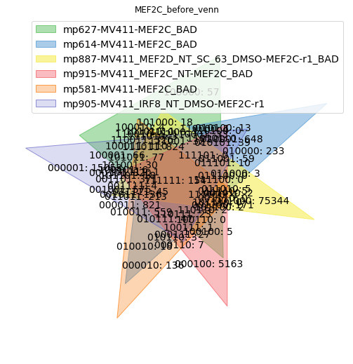

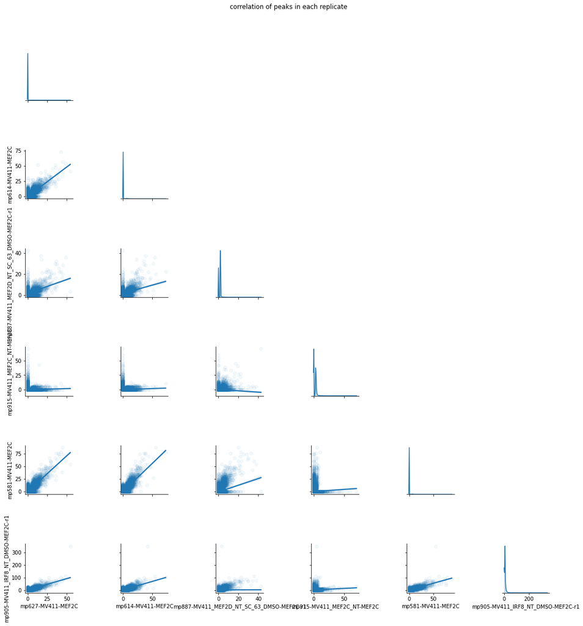

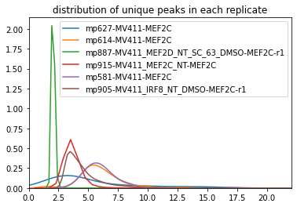

```
-> main rep is: mp905-MV411_IRF8_NT_DMSO-MEF2C-r1
- mp887-MV411_MEF2D_NT_SC_63_DMSO-MEF2C-r1
  overlap: 12.06455887921242%
 --> not enough overlap
  not using this replicate from the peakmatrix
- mp581-MV411-MEF2C
  overlap: 15.940931465354033%
 --> not enough overlap
  min,max from newly found peaks: (6.055974381948793, 72.70574935646731)
  we did not had enough initial overlap.
 --> enough overlap
  min,max from newly found peaks: (0.4757003609244202, 373.56526520624453)
  we have recovered 7439 peaks, equal to 26.103586216576602% of the peaks in main replicate
  enough from small overlap to advice to merge the peaks
- mp614-MV411-MEF2C
  overlap: 14.255963650132525%
 --> not enough overlap
  min,max from newly found peaks: (6.134014378741286, 75.09572796999112)
  we did not had enough initial overlap.
 --> enough overlap
  we have recovered 7525 peaks, equal to 26.40536177977402% of the peaks in main replicate
  enough from small overlap to advice to merge the peaks
- mp627-MV411-MEF2C
  overlap: 8.050927678909504%
 --> not enough overlap
  min,max from newly found peaks: (6.2634622592137985, 40.24207040070285)
  we did not had enough initial overlap.
 --> enough overlap
  we have recovered 7575 peaks, equal to 26.580812688609726% of the peaks in main replicate
  enough from small overlap to advice to merge the peaks
- mp915-MV411_MEF2C_NT-MEF2C
  overlap: 7.411965164710336%
 --> not enough overlap
  not using this replicate from the peakmatrix
```

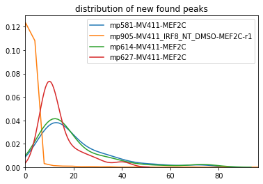

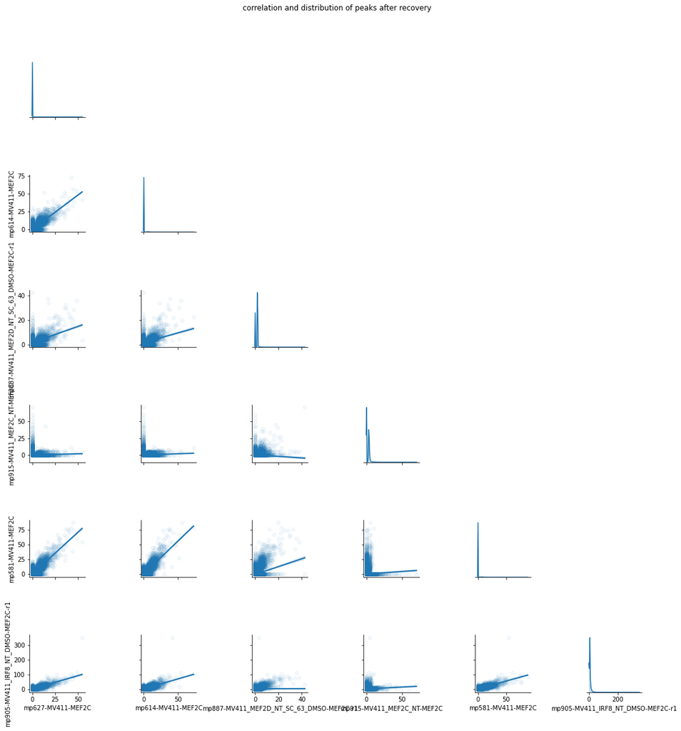

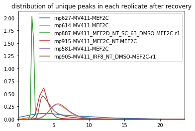

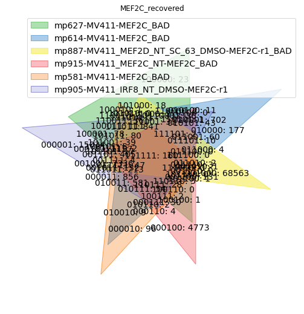

```
('MEF2C', 28498)
```

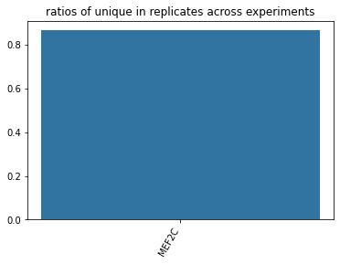

```python
%matplotlib inline
mergedpeak, tomergebam, remove, ratiosofunique = chip.mergeReplicatePeaks(bindings,         '../../data/'+project+'/wigs/bigwig/', markedasbad=bad, window=150, mincov=4, doPlot=True, minKL=10, cov={}, use='poisson', MINOVERLAP=0.25, lookeverywhere=True, only='', saveloc='../results/'+project+'/plots/'+version+'_retryMEF2C/')
```

```python
mergedpeak #= mergedpeak[mergedpeak.columns[[2,9,3,5,6,4,0,1,7,10]]]
```

|  | chrom | start | end | peak_number | foldchange | -log10pvalue | -log10qvalue | relative_summit_pos | name | tf |
| --- | --- | --- | --- | --- | --- | --- | --- | --- | --- | --- |
| 0 | chr1 | 10087 | 10317 | 0 | 5.914910 | 1.068010e+01 | 6.748430e+00 | 134 | MEF2C | MEF2C |
| 1 | chr1 | 180760 | 181047 | 1 | 4.843950 | 1.076920e+01 | 6.833590e+00 | 134 | MEF2C | MEF2C |
| 2 | chr1 | 183562 | 184551 | 2 | 3.851040 | 3.916524e+01 | 9.580449e+00 | 636 | MEF2C | MEF2C |
| 3 | chr1 | 261731 | 262752 | 3 | 2.155440 | 3.927820e+00 | 1.561020e+00 | 1021 | MEF2C | MEF2C |
| 4 | chr1 | 605257 | 605586 | 4 | 3.837510 | 5.112510e+00 | 2.433650e+00 | 329 | MEF2C | MEF2C |
| ... | ... | ... | ... | ... | ... | ... | ... | ... | ... | ... |
| 28493 | chrY | 56715020 | 56715854 | 102322 | 14.657783 | 1.485973e+05 | 9.279942e+04 | 425 | MEF2C | MEF2C |
| 28494 | chrY | 56720710 | 56721183 | 102324 | 3.987447 | 5.592550e+02 | 1.071451e+02 | 370 | MEF2C | MEF2C |
| 28495 | chrY | 56751860 | 56752350 | 102327 | 2.314990 | 1.082143e+03 | 2.585016e+02 | 203 | MEF2C | MEF2C |
| 28496 | chrY | 56763271 | 56763586 | 102329 | 1.970413 | 2.576388e+06 | 2.256173e+06 | 215 | MEF2C | MEF2C |
| 28497 | chrY | 56768533 | 56770895 | 102330 | 14.208765 | 1.980418e+07 | 1.266940e+07 | 176 | MEF2C | MEF2C |

28498 rows × 10 columns

```python
tomergebam
```

```
[['mp299-MV411-CEBPA', 'mp72-MV411-CEBPA'],
 ['mp299-MV411-CEBPA', 'mp728-MV411_DMSO-CEBPA'],
 ['mp299-MV411-CEBPA', 'mp112-MV411-CEBPA'],
 ['mp583-MV411-ELF2', 'mp607-MV411-ELF2'],
 ['mp771-MV411-JUND', 'mp772-MV411-JUND'],
 ['mp773-MV411-HOXA9', 'mp774-MV411-HOXA9'],
 ['mp718-MV411-IRF2BP2', 'mp430-MV411-IRF2BP2'],
 ['mp718-MV411-IRF2BP2', 'mp431-MV411-IRF2BP2'],
 ['mp425-MV411-ETV6', 'mp569-MV411-ETV6'],
 ['mp70-MV411-H3K27ac', 'mp702-MV411_DMSO-H3K27ac'],
 ['mp70-MV411-H3K27ac', 'mp734-MV411_DMSO-H3K27ac'],
 ['mp70-MV411-H3K27ac', 'mp88-MV411-H3K27ac'],
 ['mp70-MV411-H3K27ac', 'mp136-MV411-H3K27ac'],
 ['db55-MV411-RUNX1', 'mp300-MV411-RUNX1'],
 ['db55-MV411-RUNX1', 'mp424-MV411-RUNX1'],
 ['db55-MV411-RUNX1', 'mp129-MV411-RUNX1'],
 ['mp767-MV411-FOXP1', 'mp768-MV411-FOXP1'],
 ['mp587-MV411-IKZF1', 'mp604-MV411-IKZF1'],
 ['db46-MV411-BRD4', 'db47-MV411-BRD4'],
 ['mp325-MV411-SP1', 'mp426-MV411-SP1'],
 ['mp325-MV411-SP1', 'mp118-MV411-SP1'],
 ['mp301-MV411-PU1', 'mp428-MV411-PU1'],
 ['mp301-MV411-PU1', 'mp115-MV411-PU1'],
 ['mp357-MV411-ZMYND8', 'mp358-MV411-ZMYND8'],
 ['mp889-MV411_MEF2D_NT_SC_63_DMSO-MYC-r1', 'mp584-MV411-MYC'],
 ['mp889-MV411_MEF2D_NT_SC_63_DMSO-MYC-r1', 'mp909-MV411_IRF8_NT_DMSO-MYC-r1'],
 ['mp889-MV411_MEF2D_NT_SC_63_DMSO-MYC-r1', 'mp724-MV411_DMSO-MYC'],
 ['mp889-MV411_MEF2D_NT_SC_63_DMSO-MYC-r1', 'mp585-MV411-MYC'],
 ['mp764-MV411-RUNX2', 'mp763-MV411-RUNX2'],
 ['mp764-MV411-RUNX2', 'mp765-MV411-RUNX2'],
 ['mp764-MV411-RUNX2', 'mp601-MV411-RUNX2'],
 ['mp639-MV411-MAX', 'mp690-MV411_DMSO-MAX'],
 ['mp429-MV411-IRF8', 'mp901-MV411_IRF8_NT_DMSO-IRF8-r1'],
 ['mp429-MV411-IRF8', 'mp883-MV411_MEF2D_NT_SC_63_DMSO-IRF8-r1'],
 ['mp716-MV411-GSE1', 'mp433-MV411-GSE1'],
 ['mp106-MV411-MYB', 'mp116-MV411-MYB'],
 ['mp320-MV411-ZEB2', 'mp715-MV411-ZEB2'],
 ['mp760-MV411_MEF2D_NT_SC_63-FLAG_MEF2D',
  'mp881-MV411_MEF2D_NT_SC_63_DMSO-FLAG_MEF2D-r3'],
 ['mp760-MV411_MEF2D_NT_SC_63-FLAG_MEF2D',
  'mp919-MV411_MEF2D_NT_SC_63-FLAG_MEF2D'],
 ['mp891-MV411_MEF2D_NT_SC_63_DMSO-POLII-r1',
  'mp911-MV411_IRF8_NT_DMSO-POLII_total-r1'],
 ['mp903-MV411_IRF8_NT_DMSO-MED1-r1', 'mp435-MV411-MED1'],
 ['mp903-MV411_IRF8_NT_DMSO-MED1-r1',
  'mp885-MV411_MEF2D_NT_SC_63_DMSO-MED1-r1']]
```

```python
# TFs that you might want to remove because of their quality
remove
```

```
['WDR5', 'GATA2', 'MEF2C']
```

## sorting and removing samples

```python
rename = {'FLAG_GFI':'FLAG_GFI1', 'FLAG_PU1':'FLAG_SPI1', 'PU1':'SPI1', 'ZFP281':'ZNF281', 'TFP4':'TFAP4','SREBP1':'SREBF1'}
mergedpeak.tf = mergedpeak.tf.replace(rename)
```

```python
#what tfs do we have in our set?
tfs = set(mergedpeak.tf)
tfs
```

```
{'AFF4',
 'BRD4',
 'CDK13',
 'CDK9',
 'CEBPA',
 'CEBPB',
 'CTCF',
 'E2F3',
 'ELF2',
 'ETV6',
 'FLAG_GFI1',
 'FLAG_IRF2BP2',
 'FLAG_MEF2C',
 'FLAG_MEF2D',
 'FLAG_SPI1',
 'FLI1',
 'FOSL2',
 'FOXP1',
 'GATA2',
 'GFI1',
 'GSE1',
 'H3K18',
 'H3K27ac',
 'H3K27me3',
 'H3K36me2',
 'H3K36me3',
 'H3K4me1',
 'H3K4me3',
 'H3K79me2',
 'H3K9ac',
 'HEX',
 'HOXA9',
 'IKZF1',
 'IRF2BP2',
 'IRF8',
 'JUND',
 'LDB1',
 'LMO2',
 'LYL1',
 'MAX',
```

[output cut: 10 more lines]

```
 'PSER2',
 'RARA',
 'RUNX1',
 'RUNX2',
 'RXRA',
 'SMC1',
 'SP1',
 'SPI1',
 'SREBF1',
 'STAT5B',
 'TFAP4',
 'WDR5',
 'ZEB2',
 'ZMYND8',
 'ZNF281'}
```

```python
mergedpeak.to_csv('../results/'+project+'/large/merged_replicates_'+version+'.csv.gz')
```

```python
bigwigs=os.listdir('../../data/bigwig/')
for val in bigwigs:
    for v in remove + toremove + ['scale','POLII','IGG','CTCF','INPUT']:
        if v in val:
            bigwigs.remove(val)
            break
bigwigs = ['data/bigwig/'+ i for i in bigwigs]
```

## Consensus set

```python
window = 150
merging_version = "simpleMerge"
```

```python
#getting the crcs
crc = helper.fileToList('../data/CRCs.csv')
set(crc) - tfs ,tfs - set(crc)
crc = set(crc) -tfs
```

```python
#merging all the crc to create the cobinding matrix. keeping he flag versions
keep = ['FLAG_MEF2D','FLAG_GFI1']
remove = ['MEF2D','GFI1','FLAG_IRF2BP2','FLAG_MEF2C','FLAG_SPI1','H3K18','GSE1','HEX']
mergedpeak['name'] = mergedpeak.tf
merged = chip.simpleMergePeaks(mergedpeak[mergedpeak.tf.isin((set(crc)|set(keep))-set(remove))], window=int(window))
crc = (set(crc)|set(keep))-set(remove)
```

```
0.061202972033997920.999998232405139945
```

```python
window=str(window)
len(merged),len(mergedpeak)
```

[output not shown]

```python
# the cobinding matrix (saving it as well)
merged
```

|  | chrom | start | end | peak_number | foldchange | -log10pvalue | -log10qvalue | relative_summit_pos | CEBPA | HOXA9 | ... | TFAP4 | RUNX2 | MAX | IRF8 | MYB | ZEB2 | RXRA | SPI1 | MEF2C | FLAG_MEF2D |
| --- | --- | --- | --- | --- | --- | --- | --- | --- | --- | --- | --- | --- | --- | --- | --- | --- | --- | --- | --- | --- | --- |
| 0 | chr1 | 9936 | 10300 | 0 | 10.264422 | 31242.919925 | 20942.926956 | 107 | 0.0 | 0.0 | ... | 20.13070 | 5.750405 | 0.0 | 0.00000 | 0.0 | 0.0 | 8.51315 | 0.0 | 0.00000 | 3.86739 |
| 1 | chr1 | 15524 | 15801 | 1 | 3.326400 | 9.112810 | 7.086980 | 277 | 0.0 | 0.0 | ... | 0.00000 | 0.000000 | 0.0 | 0.00000 | 0.0 | 0.0 | 0.00000 | 0.0 | 0.00000 | 0.00000 |
| 2 | chr1 | 29182 | 29649 | 2 | 15.734000 | 43.992500 | 40.043900 | 145 | 0.0 | 0.0 | ... | 0.00000 | 0.000000 | 0.0 | 0.00000 | 0.0 | 0.0 | 0.00000 | 0.0 | 0.00000 | 0.00000 |
| 3 | chr1 | 180636 | 182055 | 3 | 6.703357 | 106618.940101 | 24609.011579 | 144 | 0.0 | 0.0 | ... | 6.51873 | 0.000000 | 0.0 | 0.00000 | 0.0 | 0.0 | 0.00000 | 0.0 | 0.00000 | 4.68577 |
| 4 | chr1 | 183251 | 183855 | 4 | 3.734692 | 20.225199 | 5.923574 | 67 | 0.0 | 0.0 | ... | 4.93771 | 0.000000 | 0.0 | 0.00000 | 0.0 | 0.0 | 0.00000 | 0.0 | 0.00000 | 0.00000 |
| ... | ... | ... | ... | ... | ... | ... | ... | ... | ... | ... | ... | ... | ... | ... | ... | ... | ... | ... | ... | ... | ... |
| 383699 | chrY | 56872906 | 56873928 | 383699 | 1.999365 | 4.855900 | 2.227570 | 240 | 0.0 | 0.0 | ... | 0.00000 | 0.000000 | 0.0 | 0.00000 | 0.0 | 0.0 | 0.00000 | 0.0 | 1.71349 | 0.00000 |
| 383700 | chrY | 56875662 | 56876207 | 383700 | 1.826950 | 4.469960 | 2.575570 | 545 | 0.0 | 0.0 | ... | 0.00000 | 0.000000 | 0.0 | 0.00000 | 0.0 | 0.0 | 0.00000 | 0.0 | 0.00000 | 0.00000 |
| 383701 | chrY | 56876514 | 56876695 | 383701 | 4.822720 | 7.796570 | 5.376070 | 56 | 0.0 | 0.0 | ... | 0.00000 | 0.000000 | 0.0 | 4.82272 | 0.0 | 0.0 | 0.00000 | 0.0 | 0.00000 | 0.00000 |
| 383702 | chrY | 56878349 | 56878890 | 383702 | 2.018205 | 4.686650 | 2.371350 | 486 | 0.0 | 0.0 | ... | 0.00000 | 0.000000 | 0.0 | 2.28084 | 0.0 | 0.0 | 0.00000 | 0.0 | 1.75557 | 0.00000 |
| 383703 | chrY | 56884676 | 56885270 | 383703 | 1.992860 | 5.622540 | 2.842030 | 594 | 0.0 | 0.0 | ... | 0.00000 | 0.000000 | 0.0 | 0.00000 | 0.0 | 0.0 | 0.00000 | 0.0 | 1.99286 | 0.00000 |

383704 rows × 37 columns

```python
merged.to_csv('../results/'+project+'/merged_'+version+'_'+merging_version+'_'+window+'.bed.gz', sep='\t',index=None)
```

```python
merged = pd.read_csv('../results/'+project+'/merged_'+version+'_'+merging_version+'_'+window+'.bed.gz', sep='\t')
```

## Plotting similarity kernels over TF binding profiles

select a set of TFs to compare

```python
cols = 8
#cols = merged.columns[cols]
```

```python
fig = sns.pairplot(merged[cols], corner=True, diag_kind="kde", kind="reg", plot_kws ={"scatter_kws":{"alpha":.05}})
def col_nan_scatter(x,y, **kwargs):
    df = pd.DataFrame({'x':x[:],'y':y[:]})
    df = df[df.sum(0)!=0]
    x = df['x']
    y = df['y']
    plt.gca()
    plt.scatter(x,y)
def col_nan_kde_histo(x, **kwargs):
    df = pd.DataFrame({'x':x[:]})
    df = df[df['x']!=0]
    x = df['x']
    plt.gca()
    sns.kdeplot(x)
fig = fig.map_upper(col_nan_scatter)
fig = fig.map_upper(col_nan_kde_histo)
fig.savefig('../results/'+project+'/plots/'+version+'_'+merging_version+'_'+window+'_pairplot_experiments.pdf')
plt.show()
counts,val = np.unique(merged[merged.columns[cols:]].astype(bool).sum(1).values, return_counts=True)
fig = sns.barplot(data=pd.DataFrame(val, index=counts,columns=['counts']).T)
fig.set_yscale("log")
fig.savefig('../results/'+project+'/plots/'+version+'_'+merging_version+'_'+window+'pairplot_experiments.pdf')
plt.show()
i = merged[merged.columns[cols:]].astype(bool).sum(1)
print(i.max(),i.mean(),i.min())
```